# BabySleep RStats Analysis - Brazil

Caspar Addyman

# Baby Sleep Analysis - Brazil

This notebook contains the `R` code to load and process data from 10 day sleep survey conducted in Sao Paulo, Brazil in June 2015. In collaboration with Procter & Gamble.

## R libraries

To install the right R packages, first run the file `BabySleepRLibraries.Rmd`.

## Loading & recoding the data

All the raw data from the 10 day sleep diary is in the file `10DAY BABY SLEEP SURVEY.sav`. Steps:

1. Load the data

```r
#load data
alldata= read_spss("10DAY BABY SLEEP SURVEY.sav")
```

```
re-encoding from UTF-8
```

### Helper functions

Parents made some estimates about durations sleep. In the raw data file these are entered in hhmm format (e.g. 90 mins = 0130). We need a helper function to process these. 999 represents a missing value so we convert that to NA.

```r
convert.hhmm<-function(hhmm){
  #convert a time stored (Numerical) in hhmm format to number of minutes
  tryCatch({
    if (abs(hhmm) == 999){
      # missing entries coded as 999 or -999
      return (NA)
    }else{
      hours <- trunc(hhmm / 100)
      mins <- 100 * (hhmm/100 - hours)
      return(hours*60 + mins)
    }
  }
  ,error=function(cond) {return(NA)}
  ,warning=function(cond) {return(NA)}
  )
}

lengthsleep<-function(tosleep, wakeup){
  #how long did baby sleep
  sleeptime <- wakeup - tosleep
  if (is.na(sleeptime)){
    return(NA)
  }else if (sleeptime < 0){
    #sleep time less that zero we add 24hours
    sleeptime<- sleeptime +  24*60*60  #1day
  }
  return (sleeptime)
}

df.Rep <- function(df, cols, findval, replaceval){
    #find particular value in subset of columns and replace with another
     df[, cols] <- ifelse(df[, cols]==findval,replaceval/findval,1) * df[, cols]
     return(df)
}

#spss has a very weird date format.
#Dates in SPSS are recorded in seconds since October 14, 1582, the date of the beginning of the Julian calendar.
#so we need to transform them!
spss2date <- function(x) as.Date(x/86400, origin = "1582-10-14")

#who went to bed when?
#measure backwards from six am
six_am<-hms::hms(6*60*60)


surveyStartDate <-as.Date('20/06/2015',format='%d/%m/%Y')
baseDateTime <-as.POSIXct('2015-06-20 00:00:00') #used for bedtime calculations
```

Copy, rename and recode the key variables.

```r
alldata$mother.age <- alldata$Q5_EXATA
alldata$education <- alldata$Q6
alldata$household.size  <- alldata$Q7
alldata$household.spouse  <- alldata$Q7A_QT_2
alldata$household.children <- alldata$Q7A_QT_3
alldata$household.relatives <- alldata$Q7A_QT_4
alldata$household.others <- alldata$Q7A_QT_5
alldata$baby.gender  <- alldata$Q8A_SEXO1


#Sleep questionnaire
alldata$sleepq.where  <- alldata$Q13
alldata$sleepq.routine  <- alldata$Q13A
alldata$sleepq.position  <- alldata$Q14   #front, back, side
alldata$sleepq.fall.asleep  <- alldata$Q15   #how fall asleep (feeding, held, etc)
alldata$sleepq.how.to.bed  <- alldata$Q16      #asleep, awake

#sleep at night
#sleep amounts in minutes and hours
alldata$sleepq.night.dur.min <-mapply(convert.hhmm,alldata$Q17_1)
alldata$sleepq.night.dur.hrs <- alldata$sleepq.night.dur.min / 60

#sleep in day
alldata$sleepq.day.dur.min  <-  mapply(convert.hhmm,alldata$Q17_2)
alldata$sleepq.day.dur.hrs  <- alldata$sleepq.day.dur.min / 60

#awake in night
alldata$sleepq.awake.night.dur.min <- mapply(convert.hhmm,alldata$Q17_3)
alldata$sleepq.awake.night.dur.hrs <- alldata$sleepq.awake.night.dur.min / 60

#long to get to sleep
alldata$sleepq.get.to.sleep.dur.min <-mapply(convert.hhmm,alldata$Q17_4)
alldata$sleepq.get.to.sleep.dur.hrs <- alldata$sleepq.get.to.sleep.dur.min/60

#when baby to sleep
alldata$sleepq.tobed <- mapply(convert.hhmm,alldata$Q17_5)

#sleep1.tobed is entered as hhmm. so minutes since midnight so convert into a time by multiplying by 60 and measuring from 6am. Complicated but it works!
bedtimehoursbefore6am  <-mapply(lengthsleep,60*alldata$sleepq.tobed,six_am)

alldata$sleepq.bedtime <- baseDateTime + six_am - bedtimehoursbefore6am
#waketime
#NOTE THiS IS ESTIMATE - based on duration which some parents may misinterpret.
alldata$sleepq.waketime <- alldata$sleepq.bedtime +  alldata$sleepq.night.dur.min * 60 + alldata$sleepq.awake.night.dur.min *60

alldata$sleepq.wake.night.YesNo <- alldata$Q18
alldata$sleepq.wake.night.Num <- alldata$Q19
alldata$sleepq.wake.reason <- alldata$Q20
alldata$sleepq.diaper.change <- alldata$Q21
alldata$sleepq.diaper.help.sleep <- alldata$Q22
alldata$sleepq.num.day.naps <- alldata$Q24
alldata$sleepq.better.active.calm.day <- alldata$Q25
alldata$sleepq.better.few.many.naps <- alldata$Q25A
alldata$sleepq.child.sleep.problem  <- alldata$Q26
alldata$sleepq.satisfied.child.sleep  <- alldata$Q27
alldata$sleepq.you.lack.sleep  <- alldata$Q28
alldata$sleepq.impacts.activtiy  <- alldata$Q28A
```

3. Calculate the scores for infant temperament (IBQ-R - Rothbart et al, 2003).

```r
#Infant behaviour questionnaire scores (IBQ-R)

#which columns count for which list?
surglist = c('Q31_1','Q31_2','Q31_7','Q31_8','Q31_13','Q31_14','Q31_15','Q31_20','Q31_21','Q31_26','Q31_27','Q31_36','Q31_37')
neglist = c('Q31_3','Q31_4','Q31_9','Q31_10','Q31_16','Q31_17','Q31_22','Q31_23','Q31_28','Q31_29','Q31_32','Q31_33')
efflist = c('Q31_5','Q31_6','Q31_11r','Q31_12','Q31_18','Q31_19','Q31_24','Q31_25','Q31_30','Q31_31','Q31_34','Q31_35')
#raw data has missing values coded as 8 so replace these with NA
#first the reverse scored item
alldata <-df.Rep(alldata, c("Q31_11"),8, NA)
#now reverse it
alldata$Q31_11r <- (8-alldata$Q31_11) #this q is reverse scored
#next all others
alldata <-df.Rep(alldata, surglist,8, NA)
alldata <-df.Rep(alldata, neglist,8, NA)
alldata <-df.Rep(alldata, efflist,8, NA)

alldata$SURGENCY <- rowMeans(alldata[,surglist],na.rm=TRUE)
alldata$NEG_AFFECT <- rowMeans(alldata[,neglist],na.rm=TRUE)
alldata$EFFORTFUL <- rowMeans(alldata[,efflist],na.rm=TRUE)
```

4. What diaper are they wearing? Divide into Premium and Ordinary brands, on basis that premium brands are more absorbent and this could affect sleep.

```r
#sleeping in more absorbent premium brand (codes P, T & M)?
alldata$PREMIUMSTRING<-ifelse((alldata$Q33_NOITE == "P" | alldata$Q33_NOITE == "T" | alldata$Q33_NOITE == "M"),"ABSORBENT","ORDINARY")
alldata$PREMIUM<-ifelse((alldata$Q33_NOITE == "P" | alldata$Q33_NOITE == "T" | alldata$Q33_NOITE == "M"),1,0)
```

5. Next we calculate the babies ages on the first day of the survey (2015-06-20).

```r
#baby ages
alldata$DOB<-as.Date(paste(alldata$Q9_DIA,alldata$Q9_MES,alldata$Q9_ANO, sep='/'),format='%d/%m/%Y')
alldata$DaysOld <- alldata$DOB
alldata$DaysOld <- as.integer(surveyStartDate-alldata$DOB)
#useful to have a label for over under 1.
alldata$OverOne <- alldata$DaysOld>365
```

6. Next relabel the interesting diary columns:

```r
#set up nicely labelled, numeric versions of diary questions
#we'll just add new columns because i can never remember r syntax for relabelling things
alldata$diary.date<-spss2date(alldata$D_DATA_FRALDA)
alldata$diary.tosleep <-alldata$D_Q1_DORMIR
alldata$diary.wakeup  <-alldata$D_Q2_ACORDAR
alldata$diary.numwakes<-alldata$D_Q3
alldata$diary.nightfeed<-alldata$D_Q5
alldata$diary.changediaper<-alldata$D_Q6
alldata$diary.diaperstate<-alldata$D_Q9

alldata$diary.happiness<-alldata$D_Q11
alldata$diary.energy<-alldata$D_Q12
alldata$diary.giggles<-alldata$D_Q13
alldata$diary.whylaughed<-alldata$D_Q14
```

### Sleeping times

Next we want to work out how long the babies slept each night based on a `going to sleep` time and a `wake` time. Need to be a little careful because mostly babies go to bed one calendar day and wake the next but sometimes they go to bed after midnight so need to handle both conditions.

```r
bedtimehoursbefore6am  <-mapply(lengthsleep,alldata$diary.tosleep,six_am)

alldata$diary.bedtime <- baseDateTime + six_am - bedtimehoursbefore6am

noonbrazil = as.POSIXct('2015-06-19 12:00:00')
alldata$relativebedtime <- as.numeric(difftime(alldata$diary.bedtime,noonbrazil,units = "hours"))
```

```r
#how long did they sleep?
alldata$diary.secondssleep <- mapply(lengthsleep, alldata$diary.tosleep,alldata$diary.wakeup)
alldata$diary.hourssleep <- alldata$diary.secondssleep /3600
alldata$diary.wakehour <-alldata$diary.wakeup /3600
#convert from a time into a data
alldata$diary.waketime <-baseDateTime + alldata$diary.wakeup
```

## Cleaning data

```r
#41 wake ups in one night? probably not! cap numwakes at 12
#ggplot(alldata, aes(diary.numwakes)) + geom_histogram(binwidth = 1)

alldata$diary.numwakes[alldata$diary.numwakes >12] <- 12
```

```r
#ggplot(alldata, aes(DaysOld)) + geom_histogram(binwidth = 25)

alldata <- alldata %>% filter(DaysOld < 800)
```

We also screen for relevant health conditions (premature, breathing problems, etc) This removes one baby with Bronchitis. And remove one participant that only gave 2 nights data

```r
alldata <- alldata %>% filter(Q12A_1 == 99)

#ID 87 only has two diary entries - so best to remove them.
# see aggregate(diary.bedtime ~ ID,FUN = N, data=alldata)
alldata <- alldata %>% filter(ID != 87)
```

### Header info

The raw data has one row per night but each infant is represented for multiple nights, with rest of values duplicated so we want a new ‘header’ array with just the infant specific info. So we skip diary entries and get R to find unique row.

```r
#Isolate the header info. by skipping the diary columns (orginal and recoded)
datahead <- alldata[,c(1:223,245:288)]

#one unique row per baby
datahead <- unique(datahead)
head(datahead)
```

|  | SbjNum | ID | Q1 | Q2 | Q3 | Q4 | Q5_EXATA | Q5_FAIXA | Q6 | Q7 | Q7A_1 | Q7A_2 | Q7A_3 | Q7A_4 | Q7A_QT_2 | Q7A_QT_3 | Q7A_QT_4 | Q7A_QT_5 | Q8 | Q8A_SEXO1 | Q8A_SEXO2 | Q8A_SEXO3 | Q8A_SEXO4 | Q8A_SEXO5 | Q8A_IDAD1 | Q8A_IDAD2 | Q8A_IDAD3 | Q8A_IDAD4 | Q8A_IDAD5 | … |
| --- | --- | --- | --- | --- | --- | --- | --- | --- | --- | --- | --- | --- | --- | --- | --- | --- | --- | --- | --- | --- | --- | --- | --- | --- | --- | --- | --- | --- | --- | --- |
| 1 | 21367984 | 1 | 1 | 1 | 10 | 2 | 20 | 2 | 4 | 6 | 2 | 3 | 4 | NA | 1 | 1 | 3 | NA | 1 | 2 | NA | NA | NA | NA | 24 | NA | NA | NA | NA | … |
| 11 | 21368925 | 2 | 1 | 1 | 10 | 2 | 34 | 3 | 1 | 6 | 2 | 3 | 4 | NA | 1 | 1 | 2 | NA | 1 | 1 | NA | NA | NA | NA | 10 | NA | NA | NA | NA | … |
| 21 | 21484873 | 3 | 1 | 1 | 10 | 2 | 30 | 3 | 3 | 3 | 2 | 3 | NA | NA | 1 | 1 | NA | NA | 1 | 1 | NA | NA | NA | NA | 22 | NA | NA | NA | NA | … |
| 31 | 21484872 | 4 | 1 | 1 | 10 | 2 | 35 | 3 | 3 | 5 | 2 | 3 | NA | NA | 1 | 3 | NA | NA | 1 | 1 | 2 | 2 | NA | NA | 16 | 13 | 4 | NA | NA | … |
| 41 | 21484871 | 5 | 1 | 1 | 10 | 2 | 20 | 2 | 4 | 5 | 2 | 3 | 4 | NA | 1 | 1 | 3 | NA | 1 | 2 | NA | NA | NA | NA | 13 | NA | NA | NA | NA | … |
| 51 | 21484864 | 6 | 1 | 1 | 10 | 2 | 32 | 3 | 3 | 4 | 2 | 3 | NA | NA | 1 | 2 | NA | NA | 1 | 1 | NA | NA | NA | NA | 14 | NA | NA | NA | NA | … |

## Averages per baby

Each family completed diary for 10 days so get their average scores for each diary variable

```r
#calculate averages for each baby..
#avg bedtime
dt <- aggregate(diary.bedtime ~ ID,FUN = mean, data=alldata)
names(dt)[2]<-'avg.bedtime'
datahead<-left_join(x = datahead, y = dt, by = "ID")

#avg bedtime
dt <- aggregate(diary.waketime ~ ID,FUN = mean, data=alldata)
names(dt)[2]<-'avg.waketime'
datahead<-left_join(x = datahead, y = dt, by = "ID")

#average sleep?
dt <- aggregate(diary.hourssleep ~ ID,FUN = mean, data=alldata)
names(dt)[2]<-'avg.hourssleep'
datahead<-left_join(x = datahead, y = dt, by = "ID")

#average number of wakes
dt <- aggregate(diary.numwakes ~ ID,FUN = mean, data=alldata)
names(dt)[2]<-'avg.numwakes'
datahead<-left_join(x = datahead, y = dt, by = "ID")

#average happiness
dt <- aggregate(diary.happiness ~ ID,FUN = mean, data=alldata)
names(dt)[2]<-'avg.happiness'
datahead<-left_join(x = datahead, y = dt, by = "ID")

#average  energy
dt <- aggregate(diary.energy ~ ID,FUN = mean, data=alldata)
names(dt)[2]<-'avg.energy'
datahead<-left_join(x = datahead, y = dt, by = "ID")

#average giggliness
dt <- aggregate(diary.giggles ~ ID,FUN = mean, data=alldata)
names(dt)[2]<-'avg.giggly'
datahead<-left_join(x = datahead, y = dt, by = "ID")
```

#### Save our game!

We’ve tidied the data so save these data structures so we don’t have to do that again.

```r
saveRDS(alldata, file = "alldata.rds")
saveRDS(datahead, file = "datahead.rds")
```

## Main Analyses

### Reload pre-processed data…

```r
alldata = readRDS(file = "alldata.rds")
datahead = readRDS(file = "datahead.rds")
```

## Participant info & Descriptive stats

We will build a data.frame of summary info for the paper.

We have data from 114 babies (51 female). The survey was filled in by 114 mothers, average age 29.57 +/- 6.343 years. The average age of the babies was 419.772 +/- 199.472.

```r
#baby age
mean(datahead$DaysOld)
```

```
[1] 420
```

```r
sd(datahead$DaysOld)
```

```
[1] 199
```

```r
#parent age
mean(datahead$Q5_EXATA)
```

```
[1] 29.6
```

```r
sd(datahead$Q5_EXATA)
```

```
[1] 6.34
```

Mothers education, Household size

```r
table(datahead$Q6)
```

```
 1  2  3  4  5  6  7
14 11 54 15  8  9  3
```

```r
mean(datahead$household.size)
```

```
[1] 4.34
```

```r
sd(datahead$household.size)
```

```
[1] 1.71
```

```r
N = nrow(datahead)
table(datahead$sleepq.where)
```

```
 1  2  3  4
25 10 35 44
```

```r
table(datahead$sleepq.where) /N  #percentages
```

```
     1      2      3      4
0.2193 0.0877 0.3070 0.3860
```

```r
table(datahead$Q13A) #baby sleep routine?
```

```
 1  2  3
45  5 64
```

```r
table(datahead$Q13A) /N  #percentages
```

```
     1      2      3
0.3947 0.0439 0.5614
```

```r
table(datahead$sleepq.child.sleep.problem)
```

```
  1   2   3
  1   2 111
```

```r
table(datahead$sleepq.child.sleep.problem)/N  #percentages
```

```
      1       2       3
0.00877 0.01754 0.97368
```

```r
table(datahead$sleepq.satisfied.child.sleep)
```

```
  1   2   3
108   3   3
```

```r
table(datahead$sleepq.satisfied.child.sleep)/N  #percentages
```

```
     1      2      3
0.9474 0.0263 0.0263
```

### Bedtime & Waketime

Let’s start with the basics

```r
#sleepq bedtime
mean(datahead$sleepq.bedtime)
```

```
[1] "2015-06-19 21:52:51 BST"
```

```r
sd(datahead$sleepq.bedtime)/60
```

```
[1] 76.7
```

```r
#diary bedtime
mean(alldata$diary.bedtime)
```

```
[1] "2015-06-19 22:01:57 BST"
```

```r
sd(alldata$diary.bedtime)/60
```

```
[1] 81.9
```

```r
sd(datahead$avg.bedtime)/60
```

```
[1] 62
```

```r
#sleepq waketime
mean(datahead$sleepq.waketime)
```

```
[1] "2015-06-20 07:32:22 BST"
```

```r
sd(datahead$sleepq.waketime)/60
```

```
[1] 144
```

```r
#diary waketime
mean(alldata$diary.waketime)
```

```
[1] "2015-06-20 07:47:40 BST"
```

```r
sd(alldata$diary.waketime)/60
```

```
[1] 92.8
```

```r
mean(datahead$avg.waketime)
```

```
[1] "2015-06-20 07:47:30 BST"
```

```r
sd(datahead$avg.waketime) /60
```

```
[1] 74.2
```

```r
mean(datahead$sleepq.wake.night.Num, na.rm = TRUE)
```

```
[1] 0.93
```

```r
sd(datahead$sleepq.wake.night.Num, na.rm = TRUE)
```

```
[1] 1.13
```

```r
#diary bedtime
mean(datahead$avg.numwakes)
```

```
[1] 0.859
```

```r
sd(datahead$avg.numwakes)
```

```
[1] 0.932
```

```r
t.test(datahead$sleepq.wake.night.Num,datahead$avg.numwakes,paired = TRUE)
```

```
    Paired t-test

data:  datahead$sleepq.wake.night.Num and datahead$avg.numwakes
t = 0.7, df = 113, p-value = 0.5
alternative hypothesis: true difference in means is not equal to 0
95 percent confidence interval:
 -0.118  0.260
sample estimates:
mean of the differences
                 0.0709
```

```r
cor.test(datahead$sleepq.wake.night.Num,datahead$avg.numwakes)
```

```
    Pearson's product-moment correlation

data:  datahead$sleepq.wake.night.Num and datahead$avg.numwakes
t = 7, df = 112, p-value = 2e-09
alternative hypothesis: true correlation is not equal to 0
95 percent confidence interval:
 0.377 0.646
sample estimates:
  cor
0.524
```

```r
mean(datahead$sleepq.day.dur.min )
```

```
[1] 126
```

```r
sd(datahead$sleepq.day.dur.min )
```

```
[1] 67.5
```

### Comparing parental estimates with sleep diary.

Since the correlations between the estimates and the averages from the diaries are quite low. Let’s make some comparisons

Bedtime

[figure not shown]

```r
ggplot(data=datahead, aes(x=sleepq.bedtime, y= avg.bedtime)) + geom_point() + labs(title = "Bedtime - Correlation between diary and questionaire. r= .36", x = "Estimate on questionnaire", y="Average from diary") +
  geom_smooth(method='lm')
```

```r
t.test(as.numeric(x=datahead$sleepq.bedtime),as.numeric(datahead$avg.bedtime), paired = TRUE)
```

```
    Paired t-test

data:  as.numeric(x = datahead$sleepq.bedtime) and as.numeric(datahead$avg.bedtime)
t = -1, df = 113, p-value = 0.2
alternative hypothesis: true difference in means is not equal to 0
95 percent confidence interval:
 -1341   242
sample estimates:
mean of the differences
                   -550
```

```r
cor.test(x=as.numeric(x=datahead$sleepq.bedtime), y= as.numeric(datahead$avg.bedtime))
```

```
    Pearson's product-moment correlation

data:  as.numeric(x = datahead$sleepq.bedtime) and as.numeric(datahead$avg.bedtime)
t = 6, df = 112, p-value = 3e-08
alternative hypothesis: true correlation is not equal to 0
95 percent confidence interval:
 0.338 0.619
sample estimates:
  cor
0.491
```

Sleep duration..

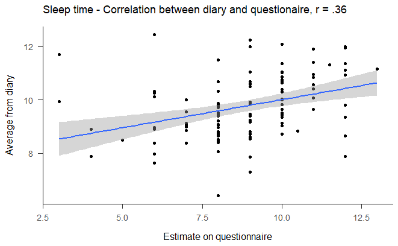

```r
theme_set(theme_apa())

ggplot(data=datahead, aes(x=sleepq.night.dur.hrs, y= avg.hourssleep)) + geom_point( ) + labs(title = "Sleep time - Correlation between diary and questionaire, r = .36", x = "Estimate on questionnaire", y="Average from diary") +
#  stat_summary(fun.data= mean_cl_normal) +
  geom_smooth(method='lm')
```

```r
cor.test(x=datahead$sleepq.night.dur.hrs, y= datahead$avg.hourssleep)
```

```
    Pearson's product-moment correlation

data:  datahead$sleepq.night.dur.hrs and datahead$avg.hourssleep
t = 4, df = 112, p-value = 9e-05
alternative hypothesis: true correlation is not equal to 0
95 percent confidence interval:
 0.187 0.509
sample estimates:
  cor
0.359
```

```r
t.test(x=datahead$sleepq.night.dur.hrs, y= datahead$avg.hourssleep, paired = TRUE)
```

```
    Paired t-test

data:  datahead$sleepq.night.dur.hrs and datahead$avg.hourssleep
t = -5, df = 113, p-value = 1e-06
alternative hypothesis: true difference in means is not equal to 0
95 percent confidence interval:
 -1.293 -0.574
sample estimates:
mean of the differences
                 -0.934
```

```r
mean(datahead$sleepq.night.dur.hrs)
```

```
[1] 8.82
```

```r
sd(datahead$sleepq.night.dur.hrs)
```

```
[1] 2.02
```

```r
mean(datahead$avg.hourssleep)
```

```
[1] 9.76
```

```r
sd(datahead$avg.hourssleep)
```

```
[1] 1.18
```

So scores are significantly correlated but only with 35% correlation rate. And parental estimates are 1 hour shorter than diary averages.

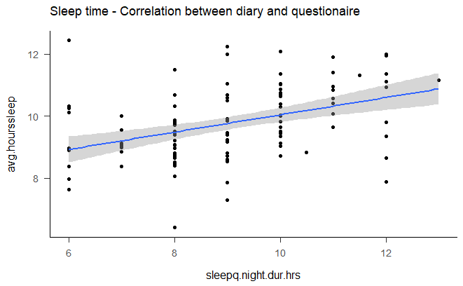

```r
datahead2 <- datahead %>% filter(sleepq.night.dur.hrs > 5)

ggplot(data=datahead2, aes(x=sleepq.night.dur.hrs, y= avg.hourssleep)) + geom_point() + labs(title = "Sleep time - Correlation between diary and questionaire") +
#  stat_summary(fun.data= mean_cl_normal) +
  geom_smooth(method='lm')
```

```r
cor.test(x=datahead2$sleepq.night.dur.hrs, y= datahead2$avg.hourssleep)
```

```
    Pearson's product-moment correlation

data:  datahead2$sleepq.night.dur.hrs and datahead2$avg.hourssleep
t = 5, df = 107, p-value = 8e-06
alternative hypothesis: true correlation is not equal to 0
95 percent confidence interval:
 0.244 0.558
sample estimates:
  cor
0.413
```

```r
t.test(x=datahead2$sleepq.night.dur.hrs, y= datahead2$avg.hourssleep, paired = TRUE)
```

```
    Paired t-test

data:  datahead2$sleepq.night.dur.hrs and datahead2$avg.hourssleep
t = -5, df = 108, p-value = 1e-05
alternative hypothesis: true difference in means is not equal to 0
95 percent confidence interval:
 -1.032 -0.409
sample estimates:
mean of the differences
                  -0.72
```

```r
mean(datahead2$sleepq.night.dur.hrs)
```

```
[1] 9.06
```

```r
mean(datahead2$avg.hourssleep)
```

```
[1] 9.78
```

This analysis confirms expectation that sleep diaries are more accurate than parental estimates. However, when asking if parents under-estimating sleep duration, we should be aware diary duration does not account for night waking (whereas parents might) Perhaps we ought to add back in their estimates of how long child was awake each night

```r
datahead$sleepq.night.adjusted.hrs <- datahead$sleepq.night.dur.hrs + datahead$sleepq.awake.night.dur.hrs

cor.test(x=datahead$sleepq.night.adjusted.hrs, y= datahead$avg.hourssleep)
```

```
    Pearson's product-moment correlation

data:  datahead$sleepq.night.adjusted.hrs and datahead$avg.hourssleep
t = 3, df = 112, p-value = 8e-04
alternative hypothesis: true correlation is not equal to 0
95 percent confidence interval:
 0.132 0.466
sample estimates:
  cor
0.309
```

```r
cor_apa(cor.test(x=datahead$sleepq.night.adjusted.hrs, y= datahead$avg.hourssleep)
, r_ci = TRUE)
```

```
r(112) = .31 [.13; .47], p < .001
```

```r
t.test(x=datahead$sleepq.night.adjusted.hrs, y= datahead$avg.hourssleep, paired = TRUE)
```

```
    Paired t-test

data:  datahead$sleepq.night.adjusted.hrs and datahead$avg.hourssleep
t = -0.5, df = 113, p-value = 0.6
alternative hypothesis: true difference in means is not equal to 0
95 percent confidence interval:
 -0.478  0.279
sample estimates:
mean of the differences
                -0.0996
```

```r
mean(datahead$sleepq.night.adjusted.hrs, na.rm = TRUE)
```

```
[1] 9.66
```

```r
sd(datahead$sleepq.night.adjusted.hrs, na.rm = TRUE)
```

```
[1] 2.07
```

```r
mean(datahead$avg.hourssleep, na.rm = TRUE)
```

```
[1] 9.76
```

```r
sd(datahead$avg.hourssleep, na.rm = TRUE)
```

```
[1] 1.18
```

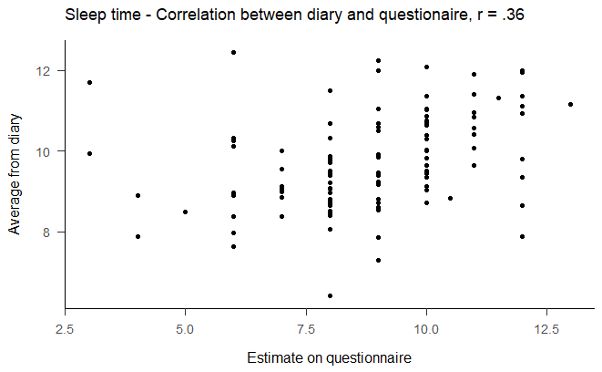

```r
ggplot(data=datahead, aes(x=sleepq.night.dur.hrs, y= avg.hourssleep )) +
 geom_point( ) + labs(title = "Sleep time - Correlation between diary and questionaire, r = .36", x = "Estimate on questionnaire", y="Average from diary")
```

We could compare the number of night wakes on both measures..

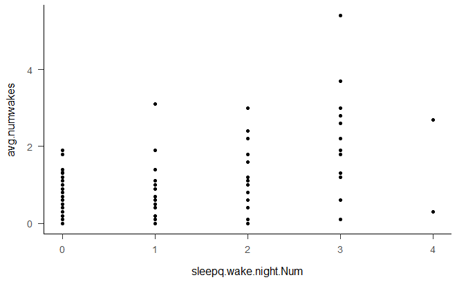

```r
ggplot(data=datahead, aes(x=sleepq.wake.night.Num, y= avg.numwakes )) +geom_point()
```

Day sleep

Av Happiness & Energy, + IBQ

```r
mean(alldata$diary.happiness)
sd(alldata$diary.happiness)

mean(alldata$diary.energy)
sd(alldata$diary.energy)

mean(alldata$SURGENCY)
sd(alldata$SURGENCY)

mean(alldata$NEG_AFFECT)
sd(alldata$NEG_AFFECT)

mean(alldata$EFFORTFUL)
sd(alldata$EFFORTFUL)
```

## What predicts sleep duration?

A good starting point for analysis is a correlogram of average diary values with some other key variables from the sleep questionnaire. We use the `corrgram` package to plot a big matrix of pairwise correlations.

```r
#Correlations
cols<-c('sleepq.night.dur.hrs', 'sleepq.day.dur.hrs', 'sleepq.wake.night.Num',
        'avg.hourssleep', 'avg.numwakes',
        'avg.happiness','avg.energy', 'avg.giggly',
        'DaysOld','SURGENCY','NEG_AFFECT','EFFORTFUL')
labs <-c('Est Sleep', 'Day sleep','Est wakes',
         'Avg Sleep', 'Avg Wakes',
         'Avg Happy', 'Avg Energy', 'Avg Giggle',
         'Days Old', 'Surgency', 'Neg Affect','Eff Control')


#corrgram(datahead[,cols],order=TRUE, lower.panel=panel.pie,
#                   upper.panel=panel.pts, text.panel=panel.txt,
#                   diag.panel=panel.minmax,
#                   main="Main Correlations in PC2/PC1 Order")


corrgram(datahead[,cols],order=FALSE, lower.panel=panel.conf,
                   upper.panel=panel.pie,
                   diag.panel=NULL, text.panel =  NULL,
                   outer.labels = list(top   =list(labels=labs, cex=1,srt=90),
                                       bottom=list(labels=labs, cex=1,srt=90),
                                       right =list(labels=labs, cex=1,srt=0),
                                       left  =list(labels=labs, cex=1,srt=0)),
                   main="Correlations")
```

[output not shown]

## Correlations

Let’s report a bunch of correlations for the paper, using the `apa` library to format the outputs.

```r
writeLines('\nBedtime - Diary vs Questionnaire')
cor_apa(cor.test(x=as.numeric(datahead$sleepq.bedtime),
                 y=as.numeric(datahead$avg.bedtime)), r_ci = TRUE)
writeLines('\nDuration - Diary vs Questionnaire')
cor_apa(cor.test(x=as.numeric(datahead$sleepq.night.dur.hrs),
                 y=as.numeric(datahead$avg.hourssleep)), r_ci = TRUE)
writeLines('\nDuration - Questionnaire Night vs Day')
cor_apa(cor.test(x=as.numeric(datahead$sleepq.night.dur.hrs),
                 y=as.numeric(datahead$sleepq.day.dur.hrs)), r_ci = TRUE)
writeLines('\nDuration - Questionnaire Night vs Num Wakes')
cor_apa(cor.test(x=as.numeric(datahead$sleepq.night.dur.hrs),
                 y=as.numeric(datahead$sleepq.wake.night.Num)), r_ci = TRUE)
writeLines('\nDuration - Diary Night vs Num Wakes')
cor_apa(cor.test(x=as.numeric(alldata$diary.hourssleep),
                 y=as.numeric(alldata$diary.numwakes)), r_ci = TRUE)
writeLines('\nDiary Sleep duration - Days Old')
cor_apa(cor.test(x=as.numeric(alldata$diary.hourssleep),
                 y=as.numeric(alldata$DaysOld)), r_ci = TRUE)
writeLines('\nDay Sleep duration - Days Old')
cor_apa(cor.test(x=as.numeric(alldata$sleepq.day.dur.hrs),
                 y=as.numeric(alldata$DaysOld)), r_ci = TRUE)
writeLines('\nDiary Sleep duration - Happiness')
cor_apa(cor.test(x=as.numeric(alldata$diary.hourssleep),
                 y=as.numeric(alldata$diary.happiness)), r_ci = TRUE)
writeLines('\nDiary Sleep duration - Energy')
cor_apa(cor.test(x=as.numeric(alldata$diary.hourssleep),
                 y=as.numeric(alldata$diary.energy)), r_ci = TRUE)

writeLines('\nDiary Happiness - Energy')
cor_apa(cor.test(x=as.numeric(alldata$diary.happiness),
                 y=as.numeric(alldata$diary.energy)), r_ci = TRUE)

writeLines('\nDiary Sleep duration - Surgency')
cor_apa(cor.test(x=as.numeric(datahead$avg.hourssleep),
                 y=as.numeric(datahead$SURGENCY)), r_ci = TRUE)

writeLines('\nDiary Sleep duration - Negative Affect')
cor_apa(cor.test(x=as.numeric(datahead$avg.hourssleep),
                 y=as.numeric(datahead$NEG_AFFECT)), r_ci = TRUE)

writeLines('\nDiary Sleep duration - Effortful Control')
cor_apa(cor.test(x=as.numeric(datahead$avg.hourssleep),
                 y=as.numeric(datahead$EFFORTFUL)), r_ci = TRUE)

writeLines('\nAvg Energy - Surgency')
cor_apa(cor.test(x=as.numeric(datahead$avg.energy),
                 y=as.numeric(datahead$SURGENCY)), r_ci = TRUE)
```

Check if sleep location or if there is routine makes a difference.

```r
aggregate(x = alldata$diary.hourssleep,                # Specify data column
          by = list(alldata$sleepq.routine),              # Specify group indicator
          FUN = mean)

datahead3 <- datahead %>% filter(sleepq.routine != 2)

whr <- aov(avg.hourssleep ~ sleepq.routine, data= datahead2)
summary.aov(whr)

aggregate(x = alldata$diary.hourssleep,                # Specify data column
          by = list(alldata$sleepq.where ),              # Specify group indicator
          FUN = mean)

whr <- aov(avg.hourssleep ~ sleepq.where, data= datahead)
summary.aov(whr)
```

## Linear Models

We use package `glmulti` to compare large set of linear models

```r
#####################
# LINEAR MODELS
####################

    #straight linear model
    glmulti.lm.out <-
    glmulti(diary.hourssleep ~ relativebedtime + DaysOld + household.size +
                sleepq.where + sleepq.routine + sleepq.day.dur.hrs +
                diary.numwakes +  diary.nightfeed +
                  PREMIUM +  diary.diaperstate + diary.changediaper +
                 + (1/SbjNum),
              data = alldata,
              level = 1,               # No interaction considered
              method = "1",            # Exhaustive approach
              crit = "aic",            # AIC as criteria
              confsetsize = 3,         # Keep 5 best models
              plotty = F, report = F,  # No plot or interim reports
              fitfunction = "lm")      # lm function
```

[output not shown]

```r
    ## Show 5 best models (Use @ instead of $ for an S4 object)
    glmulti.lm.out@formulas
```

```
[[1]]
diary.hourssleep ~ 1 + relativebedtime + DaysOld + household.size +
    sleepq.where + diary.diaperstate + diary.changediaper
<environment: 0x0000023e83336588>

[[2]]
diary.hourssleep ~ 1 + relativebedtime + DaysOld + household.size +
    sleepq.where + PREMIUM + diary.diaperstate + diary.changediaper
<environment: 0x0000023e83336588>

[[3]]
diary.hourssleep ~ 1 + relativebedtime + DaysOld + household.size +
    sleepq.where + sleepq.routine + diary.diaperstate + diary.changediaper
<environment: 0x0000023e83336588>
```

```r
    summary(glmulti.lm.out)
```

```
$name
[1] "glmulti.analysis"

$method
[1] "1"

$fitting
[1] "lm"

$crit
[1] "aic"

$level
[1] 1

$marginality
[1] FALSE

$confsetsize
[1] 3

$bestic
[1] 3958

$icvalues
[1] 3958 3959 3959

$bestmodel
[1] "diary.hourssleep ~ 1 + relativebedtime + DaysOld + household.size + "
[2] "    sleepq.where + diary.diaperstate + diary.changediaper"

$modelweights
[1] 0.487 0.266 0.247

$includeobjects
[1] TRUE
```

```r
    bestfit<-glmulti.lm.out@objects[[1]]
    summary.lm(bestfit, data = alldata)
```

```
Call:
fitfunc(formula = as.formula(x), data = data)

Residuals:
   Min     1Q Median     3Q    Max
-6.744 -0.898 -0.005  0.936  4.051

Coefficients:
                    Estimate Std. Error t value Pr(>|t|)
(Intercept)        14.566850   0.341863   42.61  < 2e-16 ***
relativebedtime    -0.556989   0.030498  -18.26  < 2e-16 ***
DaysOld             0.000728   0.000225    3.23  0.00127 **
household.size     -0.057541   0.026668   -2.16  0.03116 *
sleepq.where       -0.128214   0.041943   -3.06  0.00229 **
diary.diaperstate   0.357629   0.070702    5.06  4.9e-07 ***
diary.changediaper  0.333120   0.087881    3.79  0.00016 ***
---
Signif. codes:  0 ‘***’ 0.001 ‘**’ 0.01 ‘*’ 0.05 ‘.’ 0.1 ‘ ’ 1

Residual standard error: 1.38 on 1129 degrees of freedom
Multiple R-squared:  0.261, Adjusted R-squared:  0.257
F-statistic: 66.5 on 6 and 1129 DF,  p-value: <2e-16
```

```r
simple<-lm(diary.hourssleep ~ 1 + relativebedtime ,data = alldata)
summary.lm(simple)
```

```
Call:
lm(formula = diary.hourssleep ~ 1 + relativebedtime, data = alldata)

Residuals:
   Min     1Q Median     3Q    Max
-6.780 -0.988  0.003  0.991  3.839

Coefficients:
                Estimate Std. Error t value Pr(>|t|)
(Intercept)      15.1968     0.3117    48.8   <2e-16 ***
relativebedtime  -0.5417     0.0308   -17.6   <2e-16 ***
---
Signif. codes:  0 ‘***’ 0.001 ‘**’ 0.01 ‘*’ 0.05 ‘.’ 0.1 ‘ ’ 1

Residual standard error: 1.42 on 1134 degrees of freedom
Multiple R-squared:  0.214, Adjusted R-squared:  0.214
F-statistic:  310 on 1 and 1134 DF,  p-value: <2e-16
```

```r
aic(simple)
```

```
[1] 4017
```

Handy tool for APA format table..

```r
apa.reg.table(simple, bestfit)
```

```
Regression results using diary.hourssleep as the criterion
```

| Predictor | b | b_95%_CI | beta | beta_95%_CI | sr2 | sr2_95%_CI | r | Fit | Difference |
| --- | --- | --- | --- | --- | --- | --- | --- | --- | --- |
| (Intercept) | 15.20** | [14.59, 15.81] |  |  |  |  |  |  |  |
| relativebedtime | -0.54** | [-0.60, -0.48] | -0.46 | [-0.51, -0.41] | .21 | [.17, .25] | -.46** |  |  |
|  |  |  |  |  |  |  |  | R2 = .214** |  |
|  |  |  |  |  |  |  |  | 95% CI[.17,.25] |  |
| (Intercept) | 14.57** | [13.90, 15.24] |  |  |  |  |  |  |  |
| relativebedtime | -0.56** | [-0.62, -0.50] | -0.48 | [-0.53, -0.42] | .22 | [.18, .26] | -.46** |  |  |
| DaysOld | 0.00** | [0.00, 0.00] | 0.09 | [0.04, 0.15] | .01 | [-.00, .02] | .04 |  |  |
| household.size | -0.06* | [-0.11, -0.01] | -0.06 | [-0.11, -0.01] | .00 | [-.00, .01] | -.11** |  |  |
| sleepq.where | -0.13** | [-0.21, -0.05] | -0.09 | [-0.15, -0.03] | .01 | [-.00, .01] | -.07* |  |  |

[output cut: 5 more lines]

```
Note. A significant b-weight indicates the beta-weight and semi-partial correlation are also significant.
b represents unstandardized regression weights. beta indicates the standardized regression weights.
sr2 represents the semi-partial correlation squared. r represents the zero-order correlation.
Square brackets are used to enclose the lower and upper limits of a confidence interval.
* indicates p < .05. ** indicates p < .01.
```

```r
apa.reg.table(simple, bestfit, filename = "linear sleep dur.doc" )
```

```
Regression results using diary.hourssleep as the criterion
```

| Predictor | b | b_95%_CI | beta | beta_95%_CI | sr2 | sr2_95%_CI | r | Fit | Difference |
| --- | --- | --- | --- | --- | --- | --- | --- | --- | --- |
| (Intercept) | 15.20** | [14.59, 15.81] |  |  |  |  |  |  |  |
| relativebedtime | -0.54** | [-0.60, -0.48] | -0.46 | [-0.51, -0.41] | .21 | [.17, .25] | -.46** |  |  |
|  |  |  |  |  |  |  |  | R2 = .214** |  |
|  |  |  |  |  |  |  |  | 95% CI[.17,.25] |  |
| (Intercept) | 14.57** | [13.90, 15.24] |  |  |  |  |  |  |  |
| relativebedtime | -0.56** | [-0.62, -0.50] | -0.48 | [-0.53, -0.42] | .22 | [.18, .26] | -.46** |  |  |
| DaysOld | 0.00** | [0.00, 0.00] | 0.09 | [0.04, 0.15] | .01 | [-.00, .02] | .04 |  |  |
| household.size | -0.06* | [-0.11, -0.01] | -0.06 | [-0.11, -0.01] | .00 | [-.00, .01] | -.11** |  |  |
| sleepq.where | -0.13** | [-0.21, -0.05] | -0.09 | [-0.15, -0.03] | .01 | [-.00, .01] | -.07* |  |  |

[output cut: 5 more lines]

```
Note. A significant b-weight indicates the beta-weight and semi-partial correlation are also significant.
b represents unstandardized regression weights. beta indicates the standardized regression weights.
sr2 represents the semi-partial correlation squared. r represents the zero-order correlation.
Square brackets are used to enclose the lower and upper limits of a confidence interval.
* indicates p < .05. ** indicates p < .01.
```

## What predicts morning happiness and energy level?

```r
glmulti.lm.out <-
    glmulti(diary.happiness ~ diary.hourssleep + relativebedtime + DaysOld +
                household.size  + diary.numwakes +  diary.nightfeed +
                sleepq.where + sleepq.routine +  sleepq.day.dur.hrs +
                PREMIUM + diary.diaperstate + diary.changediaper +
                SURGENCY + NEG_AFFECT + EFFORTFUL +
               (1/SbjNum),
              data = alldata,
              level = 1,               # No interaction considered
              method = "1",            # Exhaustive approach
              crit = "aic",            # AIC as criteria
              confsetsize = 3,         # Keep 5 best models
              plotty = F, report = F,  # No plot or interim reports
              fitfunction = "lm")      # lm function
```

[output not shown]

```r
    ## Show 3 best models (Use @ instead of $ for an S4 object)
    glmulti.lm.out@formulas
```

```
[[1]]
diary.happiness ~ 1 + diary.hourssleep + relativebedtime + household.size +
    diary.numwakes + sleepq.where + sleepq.routine + sleepq.day.dur.hrs +
    PREMIUM + diary.diaperstate
<environment: 0x0000023e96975d10>

[[2]]
diary.happiness ~ 1 + diary.hourssleep + relativebedtime + household.size +
    diary.numwakes + sleepq.where + sleepq.routine + sleepq.day.dur.hrs +
    PREMIUM + diary.diaperstate + EFFORTFUL
<environment: 0x0000023e96975d10>

[[3]]
diary.happiness ~ 1 + diary.hourssleep + household.size + diary.numwakes +
    sleepq.where + sleepq.routine + sleepq.day.dur.hrs + PREMIUM +
    diary.diaperstate
<environment: 0x0000023e96975d10>
```

```r
    summary(glmulti.lm.out)
```

```
$name
[1] "glmulti.analysis"

$method
[1] "1"

$fitting
[1] "lm"

$crit
[1] "aic"

$level
[1] 1

$marginality
[1] FALSE

$confsetsize
[1] 3

$bestic
[1] 4097

$icvalues
[1] 4097 4098 4098

$bestmodel
[1] "diary.happiness ~ 1 + diary.hourssleep + relativebedtime + household.size + "
[2] "    diary.numwakes + sleepq.where + sleepq.routine + sleepq.day.dur.hrs + "
[3] "    PREMIUM + diary.diaperstate"

$modelweights
[1] 0.434 0.288 0.279

$includeobjects
[1] TRUE
```

```r
    bestfit.happiness<-glmulti.lm.out@objects[[1]]
    summary.lm(bestfit.happiness)
```

```
Call:
fitfunc(formula = as.formula(x), data = data)

Residuals:
Q11.Considering a scale from 0 to 10 where 0 is "very unhappy" and 10 "Very Happy", how happy was your baby?
   Min     1Q Median     3Q    Max
-7.049 -0.693  0.196  0.974  4.127

Coefficients:
                   Estimate Std. Error t value Pr(>|t|)
(Intercept)          9.9902     0.6026   16.58  < 2e-16 ***
diary.hourssleep     0.0637     0.0313    2.03  0.04211 *
relativebedtime     -0.0611     0.0361   -1.69  0.09080 .
household.size      -0.1479     0.0287   -5.15  3.1e-07 ***
diary.numwakes      -0.1342     0.0382   -3.51  0.00047 ***
sleepq.where         0.1378     0.0455    3.03  0.00253 **
sleepq.routine      -0.1404     0.0487   -2.88  0.00403 **
sleepq.day.dur.hrs  -0.2440     0.0399   -6.11  1.4e-09 ***
PREMIUM              0.3760     0.0928    4.05  5.5e-05 ***
diary.diaperstate   -0.4534     0.0761   -5.95  3.5e-09 ***
---
Signif. codes:  0 ‘***’ 0.001 ‘**’ 0.01 ‘*’ 0.05 ‘.’ 0.1 ‘ ’ 1

Residual standard error: 1.46 on 1126 degrees of freedom
Multiple R-squared:  0.134, Adjusted R-squared:  0.127
F-statistic: 19.4 on 9 and 1126 DF,  p-value: <2e-16
```

```r
simple.happiness <-lm(diary.happiness ~ 1 + diary.hourssleep ,data = alldata)
summary.lm(simple.happiness)
```

```
Call:
lm(formula = diary.happiness ~ 1 + diary.hourssleep, data = alldata)

Residuals:
Q11.Considering a scale from 0 to 10 where 0 is "very unhappy" and 10 "Very Happy", how happy was your baby?
   Min     1Q Median     3Q    Max
-7.298 -0.357 -0.053  0.927  2.318

Coefficients:
                 Estimate Std. Error t value Pr(>|t|)
(Intercept)        7.3026     0.2864   25.50   <2e-16 ***
diary.hourssleep   0.0948     0.0290    3.27   0.0011 **
---
Signif. codes:  0 ‘***’ 0.001 ‘**’ 0.01 ‘*’ 0.05 ‘.’ 0.1 ‘ ’ 1

Residual standard error: 1.56 on 1134 degrees of freedom
Multiple R-squared:  0.00937,   Adjusted R-squared:  0.00849
F-statistic: 10.7 on 1 and 1134 DF,  p-value: 0.00109
```

```r
aic(simple.happiness)
```

```
[1] 4234
```

```r
apa.reg.table(simple.happiness, bestfit.happiness)
```

```
Regression results using diary.happiness as the criterion
```

| Predictor | b | b_95%_CI | beta | beta_95%_CI | sr2 | sr2_95%_CI | r | Fit | Difference |
| --- | --- | --- | --- | --- | --- | --- | --- | --- | --- |
| (Intercept) | 7.30** | [6.74, 7.86] |  |  |  |  |  |  |  |
| diary.hourssleep | 0.09** | [0.04, 0.15] | 0.10 | [0.04, 0.15] | .01 | [.00, .02] | .10** |  |  |
|  |  |  |  |  |  |  |  | R2 = .009** |  |
|  |  |  |  |  |  |  |  | 95% CI[.00,.02] |  |
| (Intercept) | 9.99** | [8.81, 11.17] |  |  |  |  |  |  |  |
| diary.hourssleep | 0.06* | [0.00, 0.13] | 0.07 | [0.00, 0.13] | .00 | [-.00, .01] | .10** |  |  |
| relativebedtime | -0.06 | [-0.13, 0.01] | -0.05 | [-0.12, 0.01] | .00 | [-.00, .01] | -.09** |  |  |
| household.size | -0.15** | [-0.20, -0.09] | -0.16 | [-0.22, -0.10] | .02 | [.01, .04] | -.19** |  |  |
| diary.numwakes | -0.13** | [-0.21, -0.06] | -0.10 | [-0.15, -0.04] | .01 | [-.00, .02] | -.11** |  |  |

[output cut: 8 more lines]

```
Note. A significant b-weight indicates the beta-weight and semi-partial correlation are also significant.
b represents unstandardized regression weights. beta indicates the standardized regression weights.
sr2 represents the semi-partial correlation squared. r represents the zero-order correlation.
Square brackets are used to enclose the lower and upper limits of a confidence interval.
* indicates p < .05. ** indicates p < .01.
```

```r
apa.reg.table(simple.happiness, bestfit.happiness, filename = "linear happiness.doc" )
```

```
Regression results using diary.happiness as the criterion
```

| Predictor | b | b_95%_CI | beta | beta_95%_CI | sr2 | sr2_95%_CI | r | Fit | Difference |
| --- | --- | --- | --- | --- | --- | --- | --- | --- | --- |
| (Intercept) | 7.30** | [6.74, 7.86] |  |  |  |  |  |  |  |
| diary.hourssleep | 0.09** | [0.04, 0.15] | 0.10 | [0.04, 0.15] | .01 | [.00, .02] | .10** |  |  |
|  |  |  |  |  |  |  |  | R2 = .009** |  |
|  |  |  |  |  |  |  |  | 95% CI[.00,.02] |  |
| (Intercept) | 9.99** | [8.81, 11.17] |  |  |  |  |  |  |  |
| diary.hourssleep | 0.06* | [0.00, 0.13] | 0.07 | [0.00, 0.13] | .00 | [-.00, .01] | .10** |  |  |
| relativebedtime | -0.06 | [-0.13, 0.01] | -0.05 | [-0.12, 0.01] | .00 | [-.00, .01] | -.09** |  |  |
| household.size | -0.15** | [-0.20, -0.09] | -0.16 | [-0.22, -0.10] | .02 | [.01, .04] | -.19** |  |  |
| diary.numwakes | -0.13** | [-0.21, -0.06] | -0.10 | [-0.15, -0.04] | .01 | [-.00, .02] | -.11** |  |  |

[output cut: 8 more lines]

```
Note. A significant b-weight indicates the beta-weight and semi-partial correlation are also significant.
b represents unstandardized regression weights. beta indicates the standardized regression weights.
sr2 represents the semi-partial correlation squared. r represents the zero-order correlation.
Square brackets are used to enclose the lower and upper limits of a confidence interval.
* indicates p < .05. ** indicates p < .01.
```

```r
glmulti.lm.out <-
    glmulti(diary.energy ~ diary.hourssleep + relativebedtime + DaysOld +
                household.size  + diary.numwakes +  diary.nightfeed +
                sleepq.where + sleepq.routine +  sleepq.day.dur.hrs +
               PREMIUM + diary.diaperstate + diary.changediaper +
                SURGENCY + NEG_AFFECT + EFFORTFUL +
               (1/SbjNum),
              data = alldata,
              level = 1,               # No interaction considered
              method = "1",            # Exhaustive approach
              crit = "aic",            # AIC as criteria
              confsetsize = 3,         # Keep 5 best models
              plotty = F, report = F,  # No plot or interim reports
              fitfunction = "lm")      # lm function
```

[output not shown]

```r
    ## Show 5 best models (Use @ instead of $ for an S4 object)
    glmulti.lm.out@formulas
```

```
[[1]]
diary.energy ~ 1 + diary.hourssleep + DaysOld + household.size +
    diary.numwakes + diary.nightfeed + sleepq.where + PREMIUM +
    diary.diaperstate + diary.changediaper + SURGENCY + EFFORTFUL
<environment: 0x0000023ef5fc5430>

[[2]]
diary.energy ~ 1 + diary.hourssleep + household.size + diary.numwakes +
    diary.nightfeed + sleepq.where + PREMIUM + diary.diaperstate +
    diary.changediaper + SURGENCY + EFFORTFUL
<environment: 0x0000023ef5fc5430>

[[3]]
diary.energy ~ 1 + diary.hourssleep + DaysOld + household.size +
    diary.numwakes + diary.nightfeed + sleepq.where + PREMIUM +
    diary.diaperstate + diary.changediaper
<environment: 0x0000023ef5fc5430>
```

```r
    summary(glmulti.lm.out)
```

```
$name
[1] "glmulti.analysis"

$method
[1] "1"

$fitting
[1] "lm"

$crit
[1] "aic"

$level
[1] 1

$marginality
[1] FALSE

$confsetsize
[1] 3

$bestic
[1] 4890

$icvalues
[1] 4890 4893 4893

$bestmodel
[1] "diary.energy ~ 1 + diary.hourssleep + DaysOld + household.size + "
[2] "    diary.numwakes + diary.nightfeed + sleepq.where + PREMIUM + "
[3] "    diary.diaperstate + diary.changediaper + SURGENCY + EFFORTFUL"

$modelweights
[1] 0.654 0.192 0.155

$includeobjects
[1] TRUE
```

```r
    bestfit.energy<-glmulti.lm.out@objects[[1]]
    summary.lm(bestfit.energy)
```

```
Call:
fitfunc(formula = as.formula(x), data = data)

Residuals:
Q12.Considering a scale from 0 to 10 where 0 is "very tired" and 10 "Very Energetic", how energetic was your baby?
   Min     1Q Median     3Q    Max
-6.922 -1.434  0.201  1.507  5.280

Coefficients:
                    Estimate Std. Error t value Pr(>|t|)
(Intercept)         2.297386   0.681394    3.37  0.00077 ***
diary.hourssleep    0.266563   0.039833    6.69  3.5e-11 ***
DaysOld             0.000754   0.000359    2.10  0.03582 *
household.size     -0.179111   0.042275   -4.24  2.5e-05 ***
diary.numwakes      0.362131   0.058222    6.22  7.0e-10 ***
diary.nightfeed    -0.920610   0.150795   -6.11  1.4e-09 ***
sleepq.where        0.724547   0.068158   10.63  < 2e-16 ***
PREMIUM             0.870968   0.133142    6.54  9.2e-11 ***
diary.diaperstate   0.567742   0.109362    5.19  2.5e-07 ***
diary.changediaper  0.642358   0.142945    4.49  7.7e-06 ***
SURGENCY            0.187817   0.079594    2.36  0.01846 *
EFFORTFUL          -0.266739   0.110313   -2.42  0.01576 *
---
Signif. codes:  0 ‘***’ 0.001 ‘**’ 0.01 ‘*’ 0.05 ‘.’ 0.1 ‘ ’ 1

Residual standard error: 2.07 on 1124 degrees of freedom
Multiple R-squared:  0.331, Adjusted R-squared:  0.324
F-statistic: 50.6 on 11 and 1124 DF,  p-value: <2e-16
```

```r
simple.energy<-lm(diary.energy ~ 1 + diary.hourssleep ,data = alldata)
summary.lm(simple.energy)
```

```
Call:
lm(formula = diary.energy ~ 1 + diary.hourssleep, data = alldata)

Residuals:
Q12.Considering a scale from 0 to 10 where 0 is "very tired" and 10 "Very Energetic", how energetic was your baby?
   Min     1Q Median     3Q    Max
 -6.58  -1.21   0.72   1.77   3.96

Coefficients:
                 Estimate Std. Error t value Pr(>|t|)
(Intercept)        3.9959     0.4533    8.82  < 2e-16 ***
diary.hourssleep   0.3262     0.0458    7.12  1.9e-12 ***
---
Signif. codes:  0 ‘***’ 0.001 ‘**’ 0.01 ‘*’ 0.05 ‘.’ 0.1 ‘ ’ 1

Residual standard error: 2.46 on 1134 degrees of freedom
Multiple R-squared:  0.0428,    Adjusted R-squared:  0.0419
F-statistic: 50.7 on 1 and 1134 DF,  p-value: 1.92e-12
```

```r
aic(simple)
```

[output not shown]

```r
apa.reg.table(simple.energy, bestfit.energy)
```

```
Regression results using diary.energy as the criterion
```

| Predictor | b | b_95%_CI | beta | beta_95%_CI | sr2 | sr2_95%_CI | r | Fit | Difference |
| --- | --- | --- | --- | --- | --- | --- | --- | --- | --- |
| (Intercept) | 4.00** | [3.11, 4.89] |  |  |  |  |  |  |  |
| diary.hourssleep | 0.33** | [0.24, 0.42] | 0.21 | [0.15, 0.26] | .04 | [.02, .07] | .21** |  |  |
|  |  |  |  |  |  |  |  | R2 = .043** |  |
|  |  |  |  |  |  |  |  | 95% CI[.02,.07] |  |
| (Intercept) | 2.30** | [0.96, 3.63] |  |  |  |  |  |  |  |
| diary.hourssleep | 0.27** | [0.19, 0.34] | 0.17 | [0.12, 0.22] | .03 | [.01, .04] | .21** |  |  |
| DaysOld | 0.00* | [0.00, 0.00] | 0.06 | [0.00, 0.11] | .00 | [-.00, .01] | .28** |  |  |
| household.size | -0.18** | [-0.26, -0.10] | -0.12 | [-0.17, -0.06] | .01 | [.00, .02] | -.03 |  |  |
| diary.numwakes | 0.36** | [0.25, 0.48] | 0.17 | [0.11, 0.22] | .02 | [.01, .04] | .12** |  |  |

[output cut: 10 more lines]

```
Note. A significant b-weight indicates the beta-weight and semi-partial correlation are also significant.
b represents unstandardized regression weights. beta indicates the standardized regression weights.
sr2 represents the semi-partial correlation squared. r represents the zero-order correlation.
Square brackets are used to enclose the lower and upper limits of a confidence interval.
* indicates p < .05. ** indicates p < .01.
```

```r
#apa.reg.table(simple.energy, filename = "linear simple energy.doc" )
#apa.reg.table(bestfit.energy, filename = "linear best energy.doc" )
apa.reg.table(simple.energy,bestfit.energy, filename = "linear energy.doc" )
```

```
Regression results using diary.energy as the criterion
```

| Predictor | b | b_95%_CI | beta | beta_95%_CI | sr2 | sr2_95%_CI | r | Fit | Difference |
| --- | --- | --- | --- | --- | --- | --- | --- | --- | --- |
| (Intercept) | 4.00** | [3.11, 4.89] |  |  |  |  |  |  |  |
| diary.hourssleep | 0.33** | [0.24, 0.42] | 0.21 | [0.15, 0.26] | .04 | [.02, .07] | .21** |  |  |
|  |  |  |  |  |  |  |  | R2 = .043** |  |
|  |  |  |  |  |  |  |  | 95% CI[.02,.07] |  |
| (Intercept) | 2.30** | [0.96, 3.63] |  |  |  |  |  |  |  |
| diary.hourssleep | 0.27** | [0.19, 0.34] | 0.17 | [0.12, 0.22] | .03 | [.01, .04] | .21** |  |  |
| DaysOld | 0.00* | [0.00, 0.00] | 0.06 | [0.00, 0.11] | .00 | [-.00, .01] | .28** |  |  |
| household.size | -0.18** | [-0.26, -0.10] | -0.12 | [-0.17, -0.06] | .01 | [.00, .02] | -.03 |  |  |
| diary.numwakes | 0.36** | [0.25, 0.48] | 0.17 | [0.11, 0.22] | .02 | [.01, .04] | .12** |  |  |

[output cut: 10 more lines]

```
Note. A significant b-weight indicates the beta-weight and semi-partial correlation are also significant.
b represents unstandardized regression weights. beta indicates the standardized regression weights.
sr2 represents the semi-partial correlation squared. r represents the zero-order correlation.
Square brackets are used to enclose the lower and upper limits of a confidence interval.
* indicates p < .05. ** indicates p < .01.
```

## Exploratory plots and analyses

### Do babies sleep better in more aborbent diapers?

There are several questions we could ask…

Do they sleep longer?

```r
t.test(avg.hourssleep ~ PREMIUM,data = datahead,var.equal = TRUE)
```

Do they wake up less often in more aborbent diapers?

```r
t.test(avg.numwakes ~ PREMIUM,data = datahead,var.equal = TRUE)
```

Do they wake up happier in more aborbent diapers?

```r
t.test(avg.happiness ~ PREMIUM,data = datahead,var.equal = TRUE)
```

Do they wake up more energetic in more aborbent diapers?

```r
t.test(avg.energy ~ PREMIUM,data = datahead,var.equal = TRUE)
```

```r
###
#Filter by age?
#alldata<-subset(alldata,OverOne==TRUE)
#datahead<-subset(datahead,OverOne==TRUE)
table(datahead$PREMIUM)

table(alldata$happiness)


#in separate room?
table(datahead$Q13)
aggregate(DaysOld ~ sleepq.where, FUN=mean, data=alldata)
aggregate(avg.hourssleep ~ sleepq.where, FUN=mean, data=alldata)
aggregate(avg.numwakes ~ sleepq.where, FUN=mean, data=datahead)
aggregate(avg.happiness ~ sleepq.where, FUN=mean, data=datahead)
aggregate(avg.energy ~ sleepq.where, FUN=mean, data=datahead)
aggregate(avg.giggly ~ sleepq.where, FUN=mean, data=datahead)
wheresleep<-aggregate(cbind(DaysOld,hourssleep,numwakes,happiness,energy,giggly) ~ sleepq.where, FUN=mean, data=datahead)
#write.xlsx(wheresleep, 'pampers.wheresleep.xlsx')

#Q27 - sleep problems?
aggregate(hourssleep ~ Q27, FUN=mean, data=alldata)
aggregate(happiness ~ Q27, FUN=mean, data=alldata)
aggregate(energy ~ Q27, FUN=mean, data=alldata)
```

```r
#####################
## GGGRAPHS!!!    ###
 #####################
theme_set(theme_few(base_size = 18))

#generate means
hs<-aggregate(hourssleep ~ PREMIUM, FUN=mean, data=datahead)
g1<-ggplot(datahead,aes(hourssleep))
(g1+geom_density()
  + aes(fill=as.factor(PREMIUM))
    + geom_density(alpha=.3)
    + xlim(c(4,14))
    + xlab("Hours sleep per night")
    + ggtitle("Average hours sleep")
    + facet_grid(PREMIUM~.)
    + theme(legend.position = "none",
            strip.text.y=element_text(size = 24),
            axis.title.y=element_blank(),
            axis.ticks = element_blank(),
            axis.text.y = element_blank(),
            axis.text=element_text(size=24),
            axis.title=element_text(size=18))
)
#    + geom_vline(data=hs, aes(xintercept=hourssleep,
#            linetype="dashed", size=1))
ggsave("hourssleep.png", plot = g1, height = 4, width = 6)

(ggplot(alldata ,aes(numwakes))+geom_density()
 + facet_grid(PREMIUM~.)
+ ggtitle("Number of wakes per night"))
```

```r
(ggplot(datahead,aes(happiness))
  + geom_density()
  + ggtitle("Happiness")
  + aes(fill=as.factor(PREMIUM))
  + geom_density(alpha=.3)
  + xlim(c(1,10))
  + xlab("Happiness")
  + facet_grid(PREMIUM~.)
  + theme(legend.position = "none",
        strip.text.y=element_text(size = 24),
        axis.title.y=element_blank(),
        axis.ticks = element_blank(),
        axis.text.y = element_blank(),
        axis.text=element_text(size=24),
        axis.title=element_text(size=18))
)

(ggplot(datahead,aes(energy))
+ geom_density()
+ ggtitle("Energy")
+ aes(fill=as.factor(PREMIUM))
+ geom_density(alpha=.3)
+ xlim(c(1,10))
+ xlab("Energy")
+ facet_grid(PREMIUM~.)
+ theme(legend.position = "none",
        strip.text.y=element_text(size = 24),
        axis.title.y=element_blank(),
        axis.ticks = element_blank(),
        axis.text.y = element_blank(),
        axis.text=element_text(size=24),
        axis.title=element_text(size=18))
)

(ggplot(datahead,aes(giggly))+geom_density()
 + facet_grid(PAMPERS~.) + xlim(1,5)
  + ggtitle("Giggly"))
```

```r
(ggplot(datahead,aes(DaysOld,hourssleep))
+geom_point() +aes(color=as.factor(PREMIUM))
+geom_smooth(method=lm))


ggplot(datahead,aes(SURGENCY,happiness))+geom_point()+geom_smooth(method=lm)+ facet_grid(PREMIUM~.)
ggplot(datahead,aes(SURGENCY,energy))+geom_point()+geom_smooth(method=lm)+ facet_grid(PREMIUM~.)
ggplot(datahead,aes(SURGENCY,giggly))+geom_point()+geom_smooth(method=lm)+ facet_grid(PREMIUM~.)

ggplot(datahead,aes(NEG_AFFECT,happiness))+geom_point()+geom_smooth(method=lm)+ facet_grid(PREMIUM~.)
ggplot(datahead,aes(NEG_AFFECT,energy))+geom_point()+geom_smooth(method=lm)+ facet_grid(PREMIUM~.)
ggplot(datahead,aes(NEG_AFFECT,giggly))+geom_point()+geom_smooth(method=lm)+ facet_grid(PREMIUM~.)

ggplot(datahead,aes(EFFORTFUL,happiness))+geom_point()+geom_smooth(method=lm)+ facet_grid(PREMIUM~.)
ggplot(datahead,aes(EFFORTFUL,energy))+geom_point()+geom_smooth(method=lm)+ facet_grid(PREMIUM~.)
ggplot(datahead,aes(EFFORTFUL,giggly))+geom_point()+geom_smooth(method=lm)+ facet_grid(PREMIUM~.)
```

```r
########################
## Press release figures
#####################

### 1 ###
#how happy was your baby
alldata$over8<-ifelse(alldata$happiness>7,"blue","skyblue")
table(alldata$over8)
write.csv(table(alldata$happiness),"happiness.csv")
ggplot(alldata,aes(happiness, fill = over8)) +
  scale_x_discrete(limits=1:10) +
  geom_bar(binwidth=1,origin=0.5) +
  xlab("Happiness") +
  ggtitle("On a scale of 1 to 10 how happy\n was your baby this morning?") +
  annotate("text",x=9,y=140,label="80%",size =18) +
  theme(legend.position = "none",
        strip.text.y=element_text(size = 24),
        axis.title.y=element_blank(),
        axis.ticks = element_blank(),
        axis.text.y = element_blank(),
        axis.text=element_text(size=18),
        axis.title=element_text(size=18))
#how energetic.
alldata$over82<-ifelse(alldata$energy>7,"blue","skyblue")
t(table(alldata$over82))
t(table(alldata$energy))
write.csv(table(alldata$energy),"energy.csv")
ggplot(alldata,aes(energy, fill = over82)) +
  scale_x_discrete(limits=1:10) +
  geom_bar(binwidth=1,origin=0.5) +
  xlab("Energy") +
  ggtitle("On a scale of 1 to 10 how energetic\n was your baby this morning?") +
  annotate("text",x=9,y=95,label="60%",size =18) +
  theme(legend.position = "none",
        strip.text.y=element_text(size = 24),
        axis.title.y=element_blank(),
        axis.ticks = element_blank(),
        axis.text.y = element_blank(),
        axis.text=element_text(size=18),
        axis.title=element_text(size=18))
```

```r
### 2 ###

hlm<-lm(happiness ~ numwakes + PREMIUM + hourssleep + PREMIUM*hourssleep + (1/SbjNum),data=alldata)
summary.lm(hlm)

elm<-lm(energy ~ numwakes + hourssleep*PREMIUM,data=alldata)
summary.lm(elm)
```

```r
ggplot(alldata,aes(diary.hourssleep,bedrelativetomidnight)) +
  geom_jitter() +
  geom_smooth(method=lm) +
  scale_y_continuous(breaks = c(0,-2,-4), labels=c("0" = "12 PM", "-2" = "10 PM","-4"= "8 PM")) +
  xlab("Hours of sleep") + ylab("Bedtime") +
  theme(legend.position = "none")
cor.test(alldata$hourssleep,alldata$bedrelativetomidnight,use = "pairwise.complete.obs")

ggplot(alldata,aes(happiness,numwakes)) +
  geom_jitter() +
  geom_smooth(method=lm) +
  xlab("Happiness") + ylab("Number of wakes") +
  theme(legend.position = "none")
cor.test(alldata$hourssleep,alldata$bedrelativetomidnight,use = "pairwise.complete.obs")


ggplot(alldata,aes(hourssleep,happiness)) +
  aes(color=as.factor(PREMIUM)) +
  geom_smooth(method=lm,size=1.5) +
  facet_grid(.~PREMIUM) +
  xlab("Hours of sleep") + ylab("Happiness score") +
  theme(legend.position = "none")

ggplot(alldata,aes(hourssleep,energy)) +
  aes(color=as.factor(PREMIUM)) +
  geom_smooth(method=lm,size=1.5) +
  facet_grid(.~PREMIUM) +
  xlab("Hours of sleep") + ylab("Energy score") +
  theme(legend.position = "none")
```

```r
#question 3
ggplot(alldata,aes(numwakes,happiness)) +
  geom_smooth(method=lm,size=1.5) +
  xlab("Number of wakes") + ylab("Happiness score") +
  theme(legend.position = "none")

ggplot(alldata,aes(numwakes,energy)) +
  geom_smooth(method=lm,size=1.5) +
  xlab("Number of wakes") + ylab("Energy score") +
  theme(legend.position = "none")

    p1<-ggplot(alldata,aes(DaysOld,hourssleep)) +
      geom_smooth(method=lm,size=1.5) +
      xlab("Age (days)") + ylab("Hours sleep") +
      ggtitle("Hours sleep") +
      theme(legend.position ="none",
            axis.title.y = element_blank())

    p2<-ggplot(alldata,aes(DaysOld,numwakes)) +
      geom_smooth(method=lm,size=1.5) +
      xlab("Age (days)") + ylab("Number of wakes") +
      ggtitle("Number of wakes") +
      theme(legend.position = "none",
            axis.title.y = element_blank())

    p3<-ggplot(alldata,aes(DaysOld,happiness)) +
      geom_smooth(method=lm,size=1.5) +
      xlab("Age (days)") + ylab("Happiness") +
      ggtitle("Happiness") +
      ylim(c(6,9))+
      theme(legend.position = "none",
            axis.title.y = element_blank())

    p4<-ggplot(alldata,aes(DaysOld,energy)) +
      geom_smooth(method=lm,size=1.5) +
      xlab("Age (days)") + ylab("Energy") +
      ggtitle("Energy") +
      theme(legend.position = "none",
            axis.title.y = element_blank())

    grid.arrange(p1,p2,p3,p4,ncol=4)

    grid.arrange(p3,p4,ncol=2)

    table(datahead$Q33_DIA)
    table(datahead$Q33_NOITE)

    table(alldata$PREMIUM,alldata$D_Q11)
    table(alldata$PREMIUM,alldata$D_Q12)
    #how much more laughing than usual
    table(alldata$PREMIUM,alldata$D_Q13)

    #how many times wake up?
    wakeup<-table(alldata$PREMIUM,alldata$numwakes)
    #average wakes up per night
    mean(alldata$numwakes[alldata$PREMIUM=="ABSORBENT"], na.rm=TRUE)
    mean(alldata$numwakes[alldata$PREMIUM=="ORDINARY"], na.rm =TRUE)

    mean(alldata$energy[alldata$PREMIUM=="ABSORBENT"], na.rm=TRUE)
    mean(alldata$energy[alldata$PREMIUM=="ORDINARY"], na.rm =TRUE)

    mean(alldata$happiness[alldata$PREMIUM=="ABSORBENT"], na.rm=TRUE)
    mean(alldata$happiness[alldata$PREMIUM=="ORDINARY"], na.rm =TRUE)

    #did you change your baby in the night?
    table(alldata$PREMIUM,alldata$D_Q6)

    #in the morning how was the diaper
    drywet<-table(alldata$PREMIUM,alldata$D_Q9)
    #Labels:
    #  Dry    Wet Soiled
    #   1      2      3
    drywet

    alldata$D_Q9
    drywet[1,]/sum(drywet[1,])
    drywet[2,]/sum(drywet[2,])

    mean
    summary(alldata$D_Q11)

    #wet vs happy
    aggregate(alldata$D_Q11, list(alldata$D_Q9), mean)
    wethappy<-table(alldata$D_Q9,alldata$D_Q11)
    par(mfrow=c(3,1))
    barplot(wethappy[1,],xlab = "Dry")
    barplot(wethappy[2,],xlab = "Wet")
    barplot(wethappy[3,],xlab = "Soiled")

    #wet vs energetic
    aggregate(alldata$D_Q12, list(alldata$D_Q9), mean)
    wetenergy<-table(alldata$D_Q9,alldata$D_Q12)
    par(mfrow=c(3,1))
    barplot(wetenergy[1,],xlab = "Dry")
    barplot(wetenergy[2,],xlab = "Wet")
    barplot(wetenergy[3,],xlab = "Soiled")

    #wet vs energetic
    aggregate(alldata$D_Q13, list(alldata$D_Q9), mean)
    wetgiggles<-table(alldata$D_Q9,alldata$D_Q13)
    par(mfrow=c(3,1))
    barplot(wetgiggles[1,],xlab = "Dry")
    barplot(wetgiggles[2,],xlab = "Wet")
    barplot(wetgiggles[3,],xlab = "Soiled")

    (ggplot(alldata,aes(x=D_Q11))+stat_bin(binwidth = 1,origin=0)
     + facet_grid(D_Q9~.)
     + ggtitle("Happiness vs wetness"))

    #wet vs energetic
    table(alldata$D_Q9,alldata$D_Q12)

    table(alldata$D_Q9,alldata$D_Q13)
```

```r
#word cloud

    allwords<-gsub(" me"," mom",alldata$D_Q14,ignore.case = TRUE)
    allwords<-gsub("played","play",allwords,ignore.case = TRUE)
    allwords<-gsub("playing","play",allwords,ignore.case = TRUE)
    allwords<-gsub("diapers","diaper",allwords,ignore.case = TRUE)
    allwords<-gsub("changed","change",allwords,ignore.case = TRUE)
    allwords<-gsub("watching","watch",allwords,ignore.case = TRUE)
    allwords<-gsub("saw","sees",allwords,ignore.case = TRUE)
    allwords<-gsub("nemhum","",allwords,ignore.case = TRUE)
    allwords<-gsub("with","",allwords,ignore.case = TRUE)
    allwords<-gsub("when","",allwords,ignore.case = TRUE)
    allwords<-gsub("When","",allwords,ignore.case = TRUE)
    allwords<-gsub("morning","",allwords,ignore.case = TRUE)
    wordcloud(allwords, colors=brewer.pal(8, "Dark2"),max.words=60)

    review_text <- paste(allwords, collapse=" ")
    review_source <- VectorSource(review_text)

    tmcloud<-Corpus(review_source)

    tmcloud <- tm_map(tmcloud,tolower)
    tmcloud <- tm_map(tmcloud,removeWords, stopwords("english"))
    tmcloud <- tm_map(tmcloud,removeNumbers)
    tmcloud <- tm_map(tmcloud,removePunctuation)
    tmcloud <- tm_map(tmcloud,stripWhitespace)
    tmcloud <- tm_map(tmcloud, PlainTextDocument)

    dtm <- DocumentTermMatrix(tmcloud)
    dtm2 <- as.matrix(dtm)
     m <- as.matrix(dtm)
    v <- sort(colSums(m),decreasing=TRUE)
    head(v,14)
    words <- names(v)
    d <- data.frame(word=words, freq=v)
    write.csv(d,"wordfrequencies.csv")
```

```r
    glhappiness <-
      glmulti(happiness ~ hourssleep + hourssleep:PREMIUM + relativebedtime + DaysOld + PREMIUM + numwakes +  nightfeed + diaperstate + changediaper+ (1/SbjNum),
              data = alldata,
              level = 1,               # No interaction considered
              method = "1",            # Exhaustive approach
              crit = "aic",            # AIC as criteria
              confsetsize = 5,         # Keep 5 best models
              plotty = F, report = F,  # No plot or interim reports
              fitfunction = "lm")      # lm function

    glhappiness@formulas
    summary(glhappiness@objects[[1]])

    glenergy <-
      glmulti(energy ~ hourssleep + hourssleep:PREMIUM + relativebedtime + DaysOld + PREMIUM + numwakes +  nightfeed + diaperstate + changediaper+ (1/SbjNum),
              data = alldata,
              level = 1,               # No interaction considered
              method = "1",            # Exhaustive approach
              crit = "aic",            # AIC as criteria
              confsetsize = 5,         # Keep 5 best models
              plotty = F, report = F,  # No plot or interim reports
              fitfunction = "lm")      # lm function

    glenergy@formulas
    summary(glenergy@objects[[1]])
```